# Project links

**Github repository** https://github.com/phkhle/IND320/tree/project3

**Streamlitt app** https://ind320-h2026.streamlit.app/

```python
import geopandas as gpd
import pandas as pd
import numpy as np
from shapely.geometry import Point
from pathlib import Path
import requests
import time
import matplotlib.pyplot as plt
from scipy.fft import dct, idct
from sklearn.neighbors import LocalOutlierFactor
from statsmodels.tsa.seasonal import STL

import os
import sys

# Get the parent directory of the current working directory
parent_dir = str(Path().resolve().parent)
# Add the parent directory to sys.path if it's not already there
if parent_dir not in sys.path:
    sys.path.append(parent_dir)

from NVE_API import get_nve_data

from scipy.signal import spectrogram
```

# Region boundaries and random weather locations

## Retreive the NVE regions, then rainfall areas

Read the shapefil using geopandas and using the encoding as "utf-8" to handle Norwegian characters correctly.

```python
regions = gpd.read_file("../data/shapefiles/NVE_region.shp", encoding = 'utf-8')
# . means current directory, .. means parent directory

print("Coordinate Reference System:", regions.crs)  # Coordinate Reference System
print("Column names:", regions.columns.tolist())  # List of column names

regions
```

```
Coordinate Reference System: EPSG:25833
Column names: ['OBJECTID', 'REGION', 'REGIONNAVN', 'POSTNUMMER', 'POSTSTED', 'BESØKSADR', 'ADRESSE', 'geometry']
```

|  | OBJECTID | REGION | REGIONNAVN | POSTNUMMER | POSTSTED | BESØKSADR | ADRESSE | geometry |
| --- | --- | --- | --- | --- | --- | --- | --- | --- |
| 0 | 1.0 | RV | Region Vest | 6801 | Førde | Naustdalsveien 1B | Postboks 53 | POLYGON ((193105.76 6929797.839, 191705.75 692... |
| 1 | 2.0 | RM | Region Midt-Norge | 7030 | Trondheim | Abelsgate 9, Trondheim | Abelsgate 9 | POLYGON ((391250 7388620, 392270 7386790, 3937... |
| 2 | 3.0 | RN | Region Nord | 8514 | Narvik | Kongensgate 52-54 | Kongensgate 52-54 | POLYGON ((1109096.413 7844647.502, 1105115.343... |
| 3 | 4.0 | RØ | Region Øst | 2307 | Hamar | Vangsvegen 73 | Postboks 4223 | POLYGON ((253748.22 6678130.91, 253645.58 6678... |
| 4 | 5.0 | RS | Region Sør | 3103 | Tønsberg | Anton Jenssens gate 7 | Postboks 2124 | POLYGON ((253748.22 6678130.91, 253917.63 6677... |

There are five administrative NVE regions in total, which will be used to combined into three rainfall areas:

- East (Øst) = RS + RØ
- West (Vest) = RV
- North (Nord) = RM + RN

```python
# Map NVE administrative regions to precipitation regions
region_mapping = {
    "RS": "Øst",
    "RØ": "Øst",
    "RV": "Vest",
    "RM": "Nord",
    "RN": "Nord"
}

# Assign precipitation region names
precipitation_regions = regions.copy()
precipitation_regions["region"] = precipitation_regions["REGION"].map(region_mapping)

# Merge polygons belonging to the same precipitation region
precipitation_regions = precipitation_regions.dissolve(
    by="region",
    as_index=False
)

precipitation_regions[["region"]]
```

|  | region |
| --- | --- |
| 0 | Nord |
| 1 | Vest |
| 2 | Øst |

## Retrieve the power zones (strømområdene)

```python
electricity_areas = gpd.read_file(
    "../data/shapefiles/Budområder.shp"
)

print("CRS:", electricity_areas.crs)
print("Columns:", electricity_areas.columns.tolist())
electricity_areas
```

```
CRS: EPSG:25833
Columns: ['objectid', 'budomr', 'globalid', 'st_area(sh', 'st_perimet', 'geometry']
```

|  | objectid | budomr | globalid | st_area(sh | st_perimet | geometry |
| --- | --- | --- | --- | --- | --- | --- |
| 0 | 1.0 | NO 1 | NaN | 6.052902e+10 | 1.657761e+06 | POLYGON ((337473.63 6970542.97, 337711.9 69703... |
| 1 | 2.0 | NO 2 | NaN | 6.875969e+10 | 1.256473e+06 | POLYGON ((-9833.91 6726499.86, -9836 6726404.0... |
| 2 | 3.0 | NO 3 | NaN | 1.042199e+11 | 1.773323e+06 | POLYGON ((308588.7 7261519.43, 313576.63 72590... |
| 3 | 4.0 | NO 4 | NaN | 2.032500e+11 | 3.385499e+06 | POLYGON ((973920.93 7962739.19, 974922.77 7962... |
| 4 | 5.0 | NO 5 | NaN | 3.334870e+10 | 1.106762e+06 | POLYGON ((101466.43 6881318.54, 101525.43 6881... |

There are five regions for power zones

## Generate random points for each region

Combine power and rainfall areas to use for weather data download

```python
# Standardize electricity region names
electricity_areas["region"] = (
    electricity_areas["budomr"]
    .str.replace(" ", "", regex=False)
)

# Keep only region names and geometries
electricity = electricity_areas[["region", "geometry"]]
precipitation = precipitation_regions[["region", "geometry"]]

# Ensure both datasets use the same coordinate system
precipitation = precipitation.to_crs(electricity.crs)

# Combine all eight regions
all_regions = gpd.GeoDataFrame(
    pd.concat([electricity, precipitation], ignore_index=True),
    geometry="geometry",
    crs=electricity.crs
)

print(all_regions["region"].tolist())
```

```
['NO1', 'NO2', 'NO3', 'NO4', 'NO5', 'Nord', 'Vest', 'Øst']
```

```python
import geopandas as gpd
import pandas as pd

def generate_weather_locations(regions, n_points=1000, seed=42):
    """
    Generate random weather locations for each geographic region.
    """

    # Use an equal-area projection for spatial sampling
    regions = regions.to_crs(epsg=3035).copy()

    # Sample random points within each region
    sampled = regions[["region", "geometry"]].copy()
    sampled["geometry"] = regions.geometry.sample_points(
        size=n_points,
        rng=seed
    )

    # Convert multipoints into individual rows
    sampled = sampled.explode(
        index_parts=False
    ).reset_index(drop=True)

    # Assign a unique point ID within each region
    sampled["point_id"] = (
        sampled.groupby("region").cumcount() + 1
    )

    # Convert coordinates to WGS84 for Open-Meteo
    sampled = sampled.to_crs(epsg=4326)

    sampled["longitude"] = sampled.geometry.x
    sampled["latitude"] = sampled.geometry.y

    return sampled


weather_locations = generate_weather_locations(
    all_regions,
    n_points=1000,
    seed=42
)

print(weather_locations.groupby("region").size())
```

```
region
NO1     1000
NO2     1000
NO3     1000
NO4     1000
NO5     1000
Nord    1000
Vest    1000
Øst     1000
dtype: int64
```

Save the coordinates in csv file

```python
# Save geographic coordinates for future API requests
output_dir = Path("../data/geography")
output_dir.mkdir(parents=True, exist_ok=True)

weather_locations[
    ["region", "point_id", "latitude", "longitude"]
].to_csv(
    output_dir / "weather_locations.csv",
    index=False
)

print("Saved locations:", len(weather_locations))
weather_locations
```

```
Saved locations: 8000
```

|  | region | geometry | point_id | longitude | latitude |
| --- | --- | --- | --- | --- | --- |
| 0 | NO1 | POINT (11.68444 59.75392) | 1 | 11.684436 | 59.753919 |
| 1 | NO1 | POINT (11.65588 61.63177) | 2 | 11.655883 | 61.631771 |
| 2 | NO1 | POINT (10.48523 62.38517) | 3 | 10.485228 | 62.385174 |
| 3 | NO1 | POINT (12.12426 60.87451) | 4 | 12.124261 | 60.874512 |
| 4 | NO1 | POINT (11.80075 62.25122) | 5 | 11.800748 | 62.251222 |
| ... | ... | ... | ... | ... | ... |
| 7995 | Øst | POINT (6.06891 59.21159) | 996 | 6.068909 | 59.211589 |
| 7996 | Øst | POINT (11.01143 62.42831) | 997 | 11.011430 | 62.428313 |
| 7997 | Øst | POINT (9.83699 61.59526) | 998 | 9.836991 | 61.595260 |
| 7998 | Øst | POINT (6.42913 58.94702) | 999 | 6.429128 | 58.947017 |
| 7999 | Øst | POINT (9.58962 58.69134) | 1000 | 9.589621 | 58.691340 |

8000 rows × 5 columns

## Get historical weather data from Open-Meteo (ERA5) for NO3 in 2024.

we’ll use the coordinates we’ve generated for NO3, and retrieve temperature and precipitation data from Open-Meteo.

```python
import requests
import pandas as pd

def get_era5_weather(latitude, longitude, start_date, end_date):
    """
    Download hourly ERA5 reanalysis weather data
    for a single geographic location.
    """

    url = "https://archive-api.open-meteo.com/v1/archive"

    params = {
        "latitude": latitude,
        "longitude": longitude,
        "start_date": start_date,
        "end_date": end_date,
        "hourly": "temperature_2m,precipitation",
        "models": "era5",
        "timezone": "UTC"
    }

    response = requests.get(url, params=params, timeout=60)
    response.raise_for_status()

    # The response is expected to be in JSON format, and we extract the "hourly" data
    data = response.json()["hourly"]

    df = pd.DataFrame(data)
    # Convert the "time" column to datetime format with UTC timezone
    df["time"] = pd.to_datetime(df["time"], utc=True)

    return df
```

create a region-based function that can retrieve data for multiple locations.

```python
def download_region_weather(
    region,
    start_date,
    end_date,
    locations=weather_locations,
    n_locations=1
):
    """
    Download hourly ERA5 weather data for a selected region.

    Uses previously generated geographic coordinates.
    """

    region_points = locations.loc[
        locations["region"] == region
    ].head(n_locations)

    if region_points.empty:
        raise ValueError(f"No locations found for {region}")

    results = []

    for _, point in region_points.iterrows():

        weather = get_era5_weather(
            latitude=point["latitude"],
            longitude=point["longitude"],
            start_date=start_date,
            end_date=end_date
        )

        weather["region"] = region
        weather["point_id"] = point["point_id"]

        results.append(weather)

    return pd.concat(results, ignore_index=True)
```

We now need to retrieve data for all 1,000 locations in order to calculate regional average temperature and precipitation.

However, 1,000 separate API calls are not very efficient.

--> Create a function such that we can retrieve ERA5 data for all 1,000 points in NO3 without having to send 1,000 separate requests.

--> Open-Meteo supports multiple coordinates in a single request.

--> Use Open-Meteo’s support for multiple coordinates in a single request and divide the points into groups of 10.

```python
def download_region_weather(
    region,
    start_date,
    end_date,
    locations=weather_locations,
    batch_size=10,
    n_locations=None,
    output_dir="../data/weather"
):
    """
    Download ERA5 weather data in batches.
    Save each completed batch and skip it on future runs.
    """

    points = locations.loc[
        locations["region"] == region
    ].copy()

    if n_locations is not None:
        points = points.head(n_locations)

    if points.empty:
        raise ValueError(f"No locations found for {region}")

    if batch_size < 1:
        raise ValueError("batch_size must be at least 1")

    output_path = Path(output_dir) / region
    output_path.mkdir(parents=True, exist_ok=True)

    url = "https://archive-api.open-meteo.com/v1/archive"

    for start in range(0, len(points), batch_size):

        batch = points.iloc[start:start + batch_size]

        # Include dates and point IDs to avoid mixing datasets
        first_id = batch["point_id"].iloc[0]
        last_id = batch["point_id"].iloc[-1]

        filename = (
            f"{region}_{start_date}_{end_date}_"
            f"{first_id}_{last_id}.parquet"
        )

        filepath = output_path / filename

        # Skip previously completed batches
        if filepath.exists():
            print(f"Already saved: {filename}")
            continue

        params = {
            "latitude": ",".join(
                batch["latitude"].astype(str)
            ),
            "longitude": ",".join(
                batch["longitude"].astype(str)
            ),
            "start_date": start_date,
            "end_date": end_date,
            "hourly": "temperature_2m,precipitation",
            "models": "era5",
            "timezone": "UTC"
        }

        try:
            response = requests.get(
                url,
                params=params,
                timeout=120
            )

            if response.status_code == 429:
                print("HTTP 429: API limit reached. Stopping.")
                return

            response.raise_for_status()
            data = response.json()

        except requests.RequestException as error:
            print(f"Download stopped: {error}")
            return

        if isinstance(data, dict):
            data = [data]

        if len(data) != len(batch):
            raise ValueError("Unexpected API response count")

        results = []

        for (_, point), location_data in zip(
            batch.iterrows(), data
        ):
            df = pd.DataFrame(location_data["hourly"])

            df["time"] = pd.to_datetime(
                df["time"], utc=True
            )
            df["region"] = region
            df["point_id"] = point["point_id"]

            results.append(df)

        batch_df = pd.concat(results, ignore_index=True)

        # Save completed batch
        batch_df.to_parquet(filepath, index=False)

        print(
            f"Saved {min(start + batch_size, len(points))}"
            f"/{len(points)} locations"
        )

        time.sleep(1)

    print("Download run finished.")
```

```python
download_region_weather(
    region="NO3",
    start_date="2024-01-01",
    end_date="2024-12-31",
    batch_size=10,
    n_locations=None # Download all available locations
)
```

```
Already saved: NO3_2024-01-01_2024-12-31_1_10.parquet
Already saved: NO3_2024-01-01_2024-12-31_11_20.parquet
Already saved: NO3_2024-01-01_2024-12-31_21_30.parquet
Already saved: NO3_2024-01-01_2024-12-31_31_40.parquet
Already saved: NO3_2024-01-01_2024-12-31_41_50.parquet
Already saved: NO3_2024-01-01_2024-12-31_51_60.parquet
Already saved: NO3_2024-01-01_2024-12-31_61_70.parquet
Already saved: NO3_2024-01-01_2024-12-31_71_80.parquet
Already saved: NO3_2024-01-01_2024-12-31_81_90.parquet
Already saved: NO3_2024-01-01_2024-12-31_91_100.parquet
Already saved: NO3_2024-01-01_2024-12-31_101_110.parquet
Already saved: NO3_2024-01-01_2024-12-31_111_120.parquet
Already saved: NO3_2024-01-01_2024-12-31_121_130.parquet
Already saved: NO3_2024-01-01_2024-12-31_131_140.parquet
Already saved: NO3_2024-01-01_2024-12-31_141_150.parquet
Already saved: NO3_2024-01-01_2024-12-31_151_160.parquet
Already saved: NO3_2024-01-01_2024-12-31_161_170.parquet
Already saved: NO3_2024-01-01_2024-12-31_171_180.parquet
Already saved: NO3_2024-01-01_2024-12-31_181_190.parquet
Already saved: NO3_2024-01-01_2024-12-31_191_200.parquet
Already saved: NO3_2024-01-01_2024-12-31_201_210.parquet
Already saved: NO3_2024-01-01_2024-12-31_211_220.parquet
Already saved: NO3_2024-01-01_2024-12-31_221_230.parquet
Already saved: NO3_2024-01-01_2024-12-31_231_240.parquet
Already saved: NO3_2024-01-01_2024-12-31_241_250.parquet
Already saved: NO3_2024-01-01_2024-12-31_251_260.parquet
Already saved: NO3_2024-01-01_2024-12-31_261_270.parquet
Already saved: NO3_2024-01-01_2024-12-31_271_280.parquet
Already saved: NO3_2024-01-01_2024-12-31_281_290.parquet
Already saved: NO3_2024-01-01_2024-12-31_291_300.parquet
Already saved: NO3_2024-01-01_2024-12-31_301_310.parquet
Already saved: NO3_2024-01-01_2024-12-31_311_320.parquet
Already saved: NO3_2024-01-01_2024-12-31_321_330.parquet
Already saved: NO3_2024-01-01_2024-12-31_331_340.parquet
Already saved: NO3_2024-01-01_2024-12-31_341_350.parquet
Already saved: NO3_2024-01-01_2024-12-31_351_360.parquet
Already saved: NO3_2024-01-01_2024-12-31_361_370.parquet
Already saved: NO3_2024-01-01_2024-12-31_371_380.parquet
Already saved: NO3_2024-01-01_2024-12-31_381_390.parquet
Already saved: NO3_2024-01-01_2024-12-31_391_400.parquet
```

[output cut: 46 more lines]

```
Already saved: NO3_2024-01-01_2024-12-31_861_870.parquet
Already saved: NO3_2024-01-01_2024-12-31_871_880.parquet
Already saved: NO3_2024-01-01_2024-12-31_881_890.parquet
Already saved: NO3_2024-01-01_2024-12-31_891_900.parquet
Already saved: NO3_2024-01-01_2024-12-31_901_910.parquet
Already saved: NO3_2024-01-01_2024-12-31_911_920.parquet
Already saved: NO3_2024-01-01_2024-12-31_921_930.parquet
Already saved: NO3_2024-01-01_2024-12-31_931_940.parquet
Already saved: NO3_2024-01-01_2024-12-31_941_950.parquet
Already saved: NO3_2024-01-01_2024-12-31_951_960.parquet
Already saved: NO3_2024-01-01_2024-12-31_961_970.parquet
Already saved: NO3_2024-01-01_2024-12-31_971_980.parquet
Already saved: NO3_2024-01-01_2024-12-31_981_990.parquet
Already saved: NO3_2024-01-01_2024-12-31_991_1000.parquet
Download run finished.
```

On the first run, I have downloaded weather data for 130 of 1,000 points in NO3 before it shows "HTTP 429: API limit reached. Stopping. Once the API allows new requests, I continued from point 131. I kept doing this until I got all ERA5-data for 1000 locations in NO3 throughout the whole 2024

Control that all data was downloaded correctly:

```python
# Find all saved Parquet files for NO3
folder = Path("../data/weather/NO3")


files = sorted(folder.glob("NO3_2024-01-01_2024-12-31_*.parquet"))

print("Number of files:", len(files))

# Load and combine all batches
weather_no3 = pd.concat(
    [pd.read_parquet(file) for file in files],
    ignore_index=True
)

# Check downloaded data
print("Total rows:", len(weather_no3))
print("Unique locations:", weather_no3["point_id"].nunique())
print("Unique timestamps:", weather_no3["time"].nunique())

weather_no3
```

```
Number of files: 100
Total rows: 8784000
Unique locations: 1000
Unique timestamps: 8784
```

|  | time | temperature_2m | precipitation | region | point_id |
| --- | --- | --- | --- | --- | --- |
| 0 | 2024-01-01 00:00:00+00:00 | -2.3 | 0.0 | NO3 | 101 |
| 1 | 2024-01-01 01:00:00+00:00 | -2.5 | 0.0 | NO3 | 101 |
| 2 | 2024-01-01 02:00:00+00:00 | -2.6 | 0.0 | NO3 | 101 |
| 3 | 2024-01-01 03:00:00+00:00 | -2.8 | 0.0 | NO3 | 101 |
| 4 | 2024-01-01 04:00:00+00:00 | -2.8 | 0.0 | NO3 | 101 |
| ... | ... | ... | ... | ... | ... |
| 8783995 | 2024-12-31 19:00:00+00:00 | -11.7 | 0.0 | NO3 | 1000 |
| 8783996 | 2024-12-31 20:00:00+00:00 | -12.1 | 0.0 | NO3 | 1000 |
| 8783997 | 2024-12-31 21:00:00+00:00 | -12.5 | 0.0 | NO3 | 1000 |
| 8783998 | 2024-12-31 22:00:00+00:00 | -11.8 | 0.0 | NO3 | 1000 |
| 8783999 | 2024-12-31 23:00:00+00:00 | -12.3 | 0.0 | NO3 | 1000 |

8784000 rows × 5 columns

## Visualise average precipitation in NO3 through to 2024.

To plot the average precipitation as a function of time, we calculate the average precipitation across the 1000 locations for each timepoint

```python
# Calculate average hourly precipitation across all locations
precipitation_no3 = (
    weather_no3
    .groupby("time", as_index=False)
    .agg(
        precipitation_mean=("precipitation", "mean"),
        n_locations=("point_id", "nunique")
    )
    .sort_values("time")
)

precipitation_no3
```

|  | time | precipitation_mean | n_locations |
| --- | --- | --- | --- |
| 0 | 2024-01-01 00:00:00+00:00 | 0.0043 | 1000 |
| 1 | 2024-01-01 01:00:00+00:00 | 0.0030 | 1000 |
| 2 | 2024-01-01 02:00:00+00:00 | 0.0030 | 1000 |
| 3 | 2024-01-01 03:00:00+00:00 | 0.0030 | 1000 |
| 4 | 2024-01-01 04:00:00+00:00 | 0.0029 | 1000 |
| ... | ... | ... | ... |
| 8779 | 2024-12-31 19:00:00+00:00 | 0.0785 | 1000 |
| 8780 | 2024-12-31 20:00:00+00:00 | 0.0607 | 1000 |
| 8781 | 2024-12-31 21:00:00+00:00 | 0.0564 | 1000 |
| 8782 | 2024-12-31 22:00:00+00:00 | 0.0616 | 1000 |
| 8783 | 2024-12-31 23:00:00+00:00 | 0.0599 | 1000 |

8784 rows × 3 columns

This gives us a timeseries with 8784 hourly observations, where each observation represents average precipitation in NO3

Plot the average precipitation

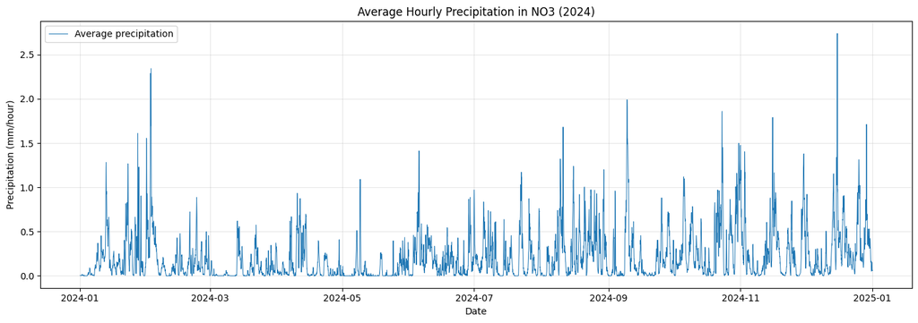

```python
fig, ax = plt.subplots(figsize=(14, 5))

ax.plot(
    precipitation_no3["time"],
    precipitation_no3["precipitation_mean"],
    linewidth=0.7,
    label="Average precipitation"
)

ax.set(
    title="Average Hourly Precipitation in NO3 (2024)",
    xlabel="Date",
    ylabel="Precipitation (mm/hour)"
)

ax.legend()
ax.grid(alpha=0.3)

plt.tight_layout()
plt.show()
```

## Removing seasonal variations in precipitation using the Discrete Cosine Transform (DCT).

We will use DCT to distinguish between slow variations and rapid changes in precipitation. We want to identify unusual precipitation levels without slow changes over the course of the year having too great an impact on the analysis.

a function for DCT high-pass filtering

```python
def dct_highpass_filter(values, cutoff=30):
    """
    Remove low-frequency variations using DCT.

    """

    values = np.asarray(values, dtype=float)

    if not 0 <= cutoff < len(values):
        raise ValueError("cutoff must be between 0 and len(values)-1")

    if not np.isfinite(values).all():
        raise ValueError("Input contains missing or infinite values")

    # Transform the signal into frequency components
    coefficients = dct(values, type=2, norm="ortho")

    # Remove low-frequency components, frequency is considered low if it is below the cutoff frequency
    coefficients[:cutoff] = 0

    # Reconstruct the high-frequency signal
    filtered = idct(coefficients, type=2, norm="ortho")

    return filtered
```

```python
# Extract average hourly precipitation
precipitation = precipitation_no3["precipitation_mean"].to_numpy()

# Apply DCT high-pass filtering
precipitation_satv = dct_highpass_filter(
    precipitation,
    cutoff=30
)

# Store the filtered values for later SPC analysis
precipitation_no3["SATV"] = precipitation_satv

print("Number of observations:", len(precipitation_satv))
print("SATV mean:", precipitation_satv.mean())
```

```
Number of observations: 8784
SATV mean: 0.0
```

DCT represents the time series as a combination of frequency components. I set the first 30 coefficients (cutoff = 30 as a preliminary parameter) to zero, we remove the slowest variations

## Statistical Process Control (SPC) to identify abnormal precipitation levels in NO3.

SPC function. I used the median and MAD (Median Absolute Deviation), which are less sensitive to outliers than the mean and standard deviation.

```python
def plot_precipitation_spc(
    df,
    cutoff=30,
    n_std=3
):
    """
    Detect precipitation outliers using DCT and robust SPC.
    """

    data = df.sort_values("time").copy()

    precipitation = data["precipitation_mean"].to_numpy()

    # 1. Remove slow variations using DCT
    satv = dct_highpass_filter(
        precipitation,
        cutoff=cutoff
    )

    # 2. Estimate robust statistics from the full year
    median = np.median(satv)
    mad = np.median(np.abs(satv - median))

    robust_std = 1.4826 * mad

    # 3. Define SPC limits in the filtered domain
    lower_limit = median - n_std * robust_std
    upper_limit = median + n_std * robust_std

    # 4. Identify outliers using SATV
    outliers = (satv < lower_limit) | (satv > upper_limit)

    # 5. Convert SPC limits to original precipitation scale
    baseline = precipitation - satv

    lower_curve = baseline + lower_limit
    upper_curve = baseline + upper_limit

    # 6. Plot original precipitation, not SATV
    fig, ax = plt.subplots(figsize=(15, 5))

    ax.plot(
        data["time"],
        precipitation,
        color="steelblue",
        linewidth=0.7,
        label="Average precipitation"
    )

    ax.plot(
        data["time"],
        upper_curve,
        color="darkorange",
        linestyle="--",
        linewidth=1,
        label="Upper SPC limit"
    )

    ax.plot(
        data["time"],
        lower_curve,
        color="green",
        linestyle="--",
        linewidth=1,
        label="Lower SPC limit"
    )

    ax.scatter(
        data.loc[outliers, "time"],
        precipitation[outliers],
        color="red",
        s=12,
        label="Outliers",
        zorder=3
    )

    ax.set(
        title="Precipitation SPC Analysis – NO3 (2024)",
        xlabel="Date",
        ylabel="Average precipitation (mm/hour)"
    )

    ax.legend()
    ax.grid(alpha=0.3)

    plt.tight_layout()

    summary = {
        "cutoff": cutoff,
        "n_std": n_std,
        "median_satv": median,
        "robust_std": robust_std,
        "lower_limit_satv": lower_limit,
        "upper_limit_satv": upper_limit,
        "n_observations": len(data),
        "n_outliers": int(outliers.sum()),
        "outlier_percentage": 100 * outliers.mean()
    }

    return fig, summary
```

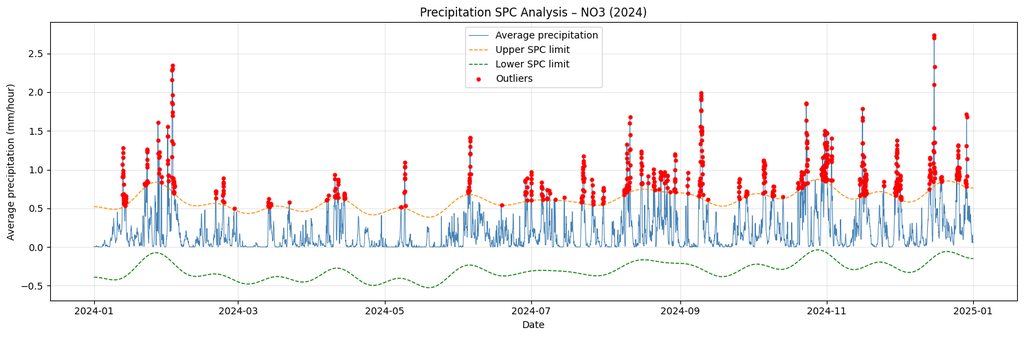

```
cutoff                  30.000000
n_std                    3.000000
median_satv             -0.055967
robust_std               0.151863
lower_limit_satv        -0.511554
upper_limit_satv         0.399621
n_observations        8784.000000
n_outliers             631.000000
outlier_percentage       7.183515
dtype: float64
```

```python
fig, summary = plot_precipitation_spc(
    precipitation_no3,
    cutoff=30,
    n_std=3
)

plt.show()

display(pd.Series(summary))
```

## Temperature analysis with Local Outlier Factor (LOF).

Calculate average temperature

```python
temperature_no3 = (
    weather_no3
    .groupby("time", as_index=False)
    .agg(
        temperature_mean=("temperature_2m", "mean")
    )
    .sort_values("time")
)

temperature_no3
```

|  | time | temperature_mean |
| --- | --- | --- |
| 0 | 2024-01-01 00:00:00+00:00 | -3.6215 |
| 1 | 2024-01-01 01:00:00+00:00 | -3.7633 |
| 2 | 2024-01-01 02:00:00+00:00 | -3.7420 |
| 3 | 2024-01-01 03:00:00+00:00 | -3.7786 |
| 4 | 2024-01-01 04:00:00+00:00 | -3.7280 |
| ... | ... | ... |
| 8779 | 2024-12-31 19:00:00+00:00 | -5.1567 |
| 8780 | 2024-12-31 20:00:00+00:00 | -5.2588 |
| 8781 | 2024-12-31 21:00:00+00:00 | -5.3605 |
| 8782 | 2024-12-31 22:00:00+00:00 | -5.2689 |
| 8783 | 2024-12-31 23:00:00+00:00 | -5.3758 |

8784 rows × 2 columns

Create a function for LOF

```python
def plot_temperature_lof(
    df,
    contamination=0.01,
    n_neighbors=20
):
    """
    Detect temperature anomalies using Local Outlier Factor.

    """

    data = df.sort_values("time").copy()

    # Extract temperature values
    temperature = data["temperature_mean"].to_numpy()

    if not np.isfinite(temperature).all():
        raise ValueError("Temperature contains missing or infinite values")

    if not 0 < contamination <= 0.5:
        raise ValueError("contamination must be between 0 and 0.5")

    # LOF expects a two-dimensional feature matrix
    X = temperature.reshape(-1, 1)

    # Initialize LOF model
    lof = LocalOutlierFactor(
        n_neighbors=n_neighbors,
        contamination=contamination
    )

    # -1 = outlier, 1 = inlier
    labels = lof.fit_predict(X)

    outliers = labels == -1

    # Plot original temperature
    fig, ax = plt.subplots(figsize=(15, 5))

    ax.plot(
        data["time"],
        temperature,
        color="steelblue",
        linewidth=0.8,
        label="Average temperature"
    )

    ax.scatter(
        data.loc[outliers, "time"],
        temperature[outliers],
        color="red",
        s=18,
        label="LOF anomalies",
        zorder=3
    )

    ax.set(
        title="Temperature Anomaly Detection – NO3 (2024)",
        xlabel="Date",
        ylabel="Average temperature (°C)"
    )

    ax.legend()
    ax.grid(alpha=0.3)

    plt.tight_layout()

    # Summary statistics
    summary = {
        "n_observations": len(data),
        "mean_temperature": float(np.mean(temperature)),
        "min_temperature": float(np.min(temperature)),
        "max_temperature": float(np.max(temperature)),
        "n_outliers": int(outliers.sum()),
        "outlier_percentage": float(outliers.mean() * 100),
        "contamination": contamination,
        "n_neighbors": n_neighbors
    }

    return fig, summary
```

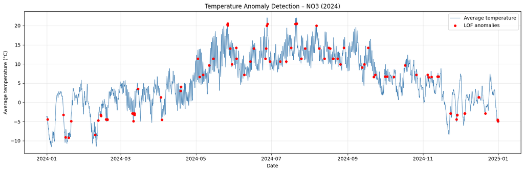

```
n_observations        8784.000000
mean_temperature         5.657643
min_temperature        -11.616300
max_temperature         22.036700
n_outliers              88.000000
outlier_percentage       1.001821
contamination            0.010000
n_neighbors             20.000000
dtype: float64
```

```python
fig, summary = plot_temperature_lof(
    temperature_no3,
    contamination=0.01,
    n_neighbors=20
)

plt.show()

pd.Series(summary)
```

We expected around 88 outiers out of 8784 observations, since contamination = 0.01 corresponds to 1%

This implementation uses only the temperature value as input to LOF.

This means that the model does not take into account the time of day or the season. LOF will therefore identify observations with unusual local density in the temperature distribution, not necessarily meteorological anomalies for the season in question.

## STL decomposition of the fill rate in Magasinstatistikk.

```python
def plot_filling_stl(
    df,
    date_col,
    value_col,
    period=52,
    seasonal=13,
    trend=105,
    robust=True
):
    """
    Perform STL decomposition on reservoir filling degree.

    """

    # Prepare time series
    data = df[[date_col, value_col]].copy()

    data[date_col] = pd.to_datetime(data[date_col])

    data = (
        data
        .sort_values(date_col)
        .set_index(date_col)
    )

    series = data[value_col].astype(float)

    if series.isna().any():
        raise ValueError("Filling degree contains missing values")

    # Perform STL decomposition
    stl = STL(
        series,
        period=period,
        seasonal=seasonal,
        trend=trend,
        robust=robust
    )

    result = stl.fit()

    # Plot decomposition
    fig = result.plot()
    fig.set_size_inches(14, 9)

    fig.suptitle(
        "STL Decomposition of Reservoir Filling Degree",
        fontsize=14,
        y=1.02
    )

    plt.tight_layout()

    # Summary statistics
    summary = {
        "n_observations": len(series),
        "period": period,
        "seasonal": seasonal,
        "trend": trend,
        "robust": robust,
        "mean_filling": float(series.mean()),
        "min_filling": float(series.min()),
        "max_filling": float(series.max()),
        "residual_std": float(result.resid.std())
    }

    return fig, summary
```

```python
# Retrieve reservoir data from NVE API
df_nve = get_nve_data()

# Select reservoir filling data for electricity area NO3
df_stl = (
    df_nve.loc[
        (df_nve["omrType"] == "EL") &
        (df_nve["omrnr"] == 3),
        ["dato_Id", "fyllingsgrad"]
    ]
    .copy()
)

# Convert date column to datetime
df_stl["dato_Id"] = pd.to_datetime(df_stl["dato_Id"])

# Sort chronologically
df_stl = df_stl.sort_values("dato_Id").reset_index(drop=True)

print("Number of observations:", len(df_stl))
print("Date range:", df_stl["dato_Id"].min(), "to", df_stl["dato_Id"].max())

df_stl
```

```
Number of observations: 1661
Date range: 1995-01-08 00:00:00 to 2026-11-01 00:00:00
```

|  | dato_Id | fyllingsgrad |
| --- | --- | --- |
| 0 | 1995-01-08 | 0.602376 |
| 1 | 1995-01-15 | 0.569943 |
| 2 | 1995-01-22 | 0.542203 |
| 3 | 1995-01-29 | 0.508148 |
| 4 | 1995-02-05 | 0.473883 |
| ... | ... | ... |
| 1656 | 2026-10-04 | 0.718754 |
| 1657 | 2026-10-11 | 0.725240 |
| 1658 | 2026-10-18 | 0.724940 |
| 1659 | 2026-10-25 | 0.717647 |
| 1660 | 2026-11-01 | 0.720149 |

1661 rows × 2 columns

We now have a single time series showing the weekly fill rate for electricity zone NO3.

STL assumes that the observations have a regular temporal resolution. We must therefore check whether any weeks are missing.

```python
# Create expected weekly dates (Sundays)
expected_dates = pd.date_range(
    start=df_stl["dato_Id"].min(),
    end=df_stl["dato_Id"].max(),
    freq="W-SUN"
)

# Identify missing weeks
missing_dates = expected_dates.difference(df_stl["dato_Id"])

# Check duplicate dates
duplicates = df_stl["dato_Id"].duplicated().sum()

print("Expected weeks:", len(expected_dates))
print("Actual observations:", len(df_stl))
print("Missing weeks:", len(missing_dates))
print("Duplicate dates:", duplicates)

display(missing_dates)
```

```
Expected weeks: 1661
Actual observations: 1661
Missing weeks: 0
Duplicate dates: 0
```

```
DatetimeIndex([], dtype='datetime64[ns]', freq='W-SUN')
```

The result shows 0 missing weeks and 0 duplicates, we can use the STL function

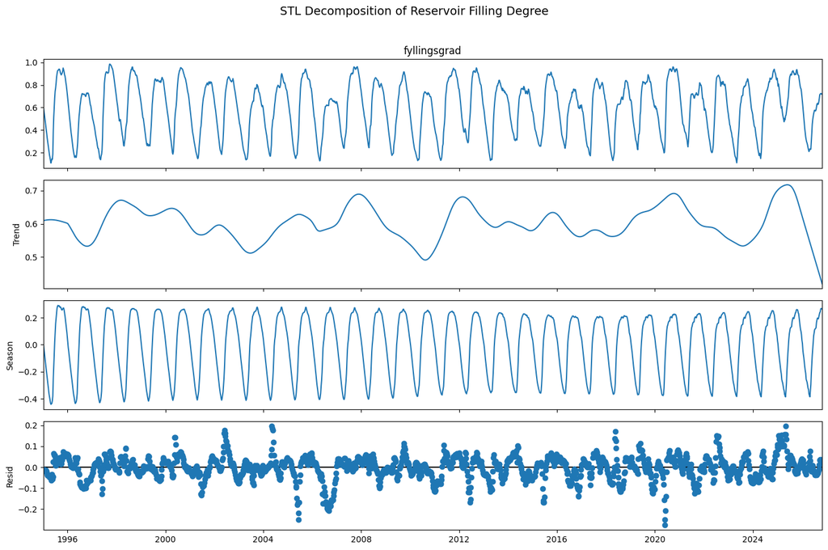

```
n_observations        1661
period                  52
seasonal                13
trend                  105
robust                True
mean_filling      0.597709
min_filling       0.107109
max_filling       0.985538
residual_std      0.056624
dtype: object
```

```python
fig, summary = plot_filling_stl(
    df=df_stl,
    date_col="dato_Id",
    value_col="fyllingsgrad",
    period=52, #  we assume an annual seasonal cycle of approximately 52 weeks.
    seasonal=13,
    trend=105,
    robust=True
)

plt.show()
display(pd.Series(summary))
```

- The fill rate varies markedly throughout the year, from approximately 0.1 to 0.95.
- Trend: The long-term fill rate fluctuates, but shows no clear sustained increase or decrease over the entire period.
- Seasonal: A strong, regular seasonal pattern recurs approximately every year.
- Residual: Most deviations are relatively small, but some periods show large positive or negative deviations.

## Spectrogram

In the STL plot, we can see a clear annual seasonal pattern. Using the spectrogram, we can investigate whether the annual cycle remains stable over the period 1995–2026.

```python
def plot_filling_spectrogram(
    df,
    date_col="dato_Id",
    value_col="fyllingsgrad",
    window_length=156,
    overlap=130
):
    """
    Plot a spectrogram of weekly reservoir filling degree.

    """

    data = df.sort_values(date_col).copy()

    values = data[value_col].to_numpy(dtype=float)

    if not np.isfinite(values).all():
        raise ValueError("Filling degree contains missing values")

    if not 0 <= overlap < window_length <= len(values):
        raise ValueError("Invalid window length or overlap")

    # Sampling frequency: one observation per week
    frequencies, times, power = spectrogram(
        values,
        fs=1.0,
        nperseg=window_length,
        noverlap=overlap,
        detrend="linear",
        scaling="spectrum"
    )

    # Convert window positions to calendar dates
    dates = pd.to_datetime(data[date_col]).reset_index(drop=True)

    time_indices = np.clip(
        np.round(times).astype(int),
        0,
        len(dates) - 1
    )

    spectrogram_dates = dates.iloc[time_indices]

    # Plot spectrogram
    fig, ax = plt.subplots(figsize=(14, 6))

    mesh = ax.pcolormesh(
        spectrogram_dates,
        frequencies,
        10 * np.log10(power + 1e-12),
        shading="auto",
        cmap="viridis"
    )

    # Mark the annual frequency
    ax.axhline(
        1 / 52,
        color="red",
        linestyle="--",
        label="Annual cycle (52 weeks)"
    )

    ax.set(
        title="Spectrogram of Reservoir Filling Degree – NO3",
        xlabel="Year",
        ylabel="Frequency (cycles/week)"
    )

    ax.legend()

    fig.colorbar(
        mesh,
        ax=ax,
        label="Power (dB)"
    )

    plt.tight_layout()

    summary = {
        "n_observations": len(values),
        "window_length": window_length,
        "overlap": overlap,
        "n_time_windows": len(times),
        "n_frequencies": len(frequencies)
    }

    return fig, summary
```

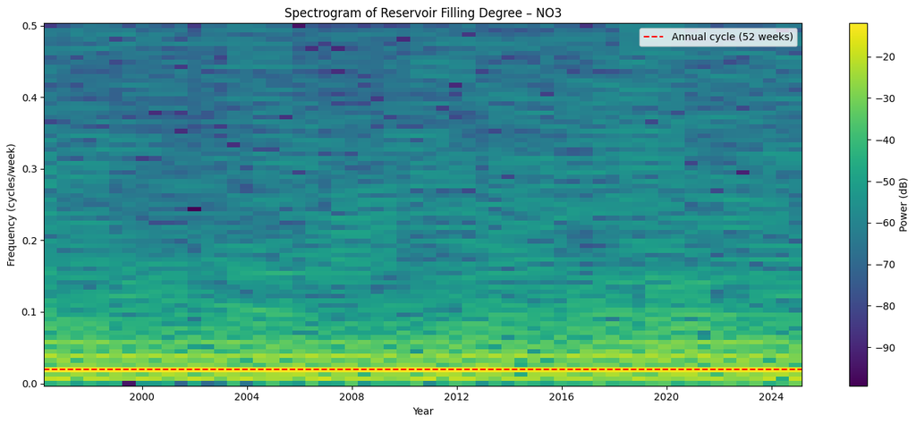

```
n_observations    1661
window_length      156
overlap            130
n_time_windows      58
n_frequencies       79
dtype: int64
```

```python
fig, summary = plot_filling_spectrogram(
    df_stl,
    window_length=156, # 3 years of weekly data
    overlap=130 # 130 weeks of overlap
)

plt.show()
display(pd.Series(summary))
```

The clearest yellow band lies around the red line, and is visible throughout almost the entire period 1995–2025. This means that the NO3 filling rate exhibits a strong cycle that repeats approximately once a year. And that the annual seasonal cycle has been a dominant component of the variation in the fill rate throughout the period.

The seasonal pattern is relatively stable

We also see some activity at higher frequencies, around 0.04–0.10 cycles per week. These represent shorter-term variations, but are considerably weaker than the annual cycle.

STL and the spectrogram both support the same main finding: the degree of fill rate in NO3 is strongly influenced by a recurring annual cycle.

## Streamlit

```python
# ============================================================
# PREPARE WEATHER DATA FOR STREAMLIT
# ============================================================

# Combine hourly regional averages
weather_hourly_no3 = precipitation_no3.merge(
    temperature_no3,
    on="time",
    how="inner"
)

# Sort chronologically
weather_hourly_no3 = (
    weather_hourly_no3
    .sort_values("time")
    .reset_index(drop=True)
)

# Create output directory
output_dir = Path("../data/weather")
output_dir.mkdir(parents=True, exist_ok=True)

# Save aggregated data
output_path = output_dir / "NO3_hourly_mean_2024.parquet"

weather_hourly_no3.to_parquet(
    output_path,
    index=False
)

print("Saved:", output_path)
print("Shape:", weather_hourly_no3.shape)

display(weather_hourly_no3.head())
```

```
Saved: ..\data\weather\NO3_hourly_mean_2024.parquet
Shape: (8784, 5)
```

|  | time | precipitation_mean | n_locations | SATV | temperature_mean |
| --- | --- | --- | --- | --- | --- |
| 0 | 2024-01-01 00:00:00+00:00 | 0.0043 | 1000 | -0.116498 | -3.6215 |
| 1 | 2024-01-01 01:00:00+00:00 | 0.0030 | 1000 | -0.117794 | -3.7633 |
| 2 | 2024-01-01 02:00:00+00:00 | 0.0030 | 1000 | -0.117787 | -3.7420 |
| 3 | 2024-01-01 03:00:00+00:00 | 0.0030 | 1000 | -0.117776 | -3.7786 |
| 4 | 2024-01-01 04:00:00+00:00 | 0.0029 | 1000 | -0.117861 | -3.7280 |

```python
from pathlib import Path
import pandas as pd

file = Path("../data/weather/NO2_hourly_mean_2024.parquet")

df = pd.read_parquet(file)

df = df.rename(columns={
    "temperature_2m": "temperature_mean",
    "precipitation": "precipitation_mean"
})

df.to_parquet(file, index=False)

print(df.columns.tolist())
```

```
['time', 'temperature_mean', 'precipitation_mean', 'n_locations']
```

# Work log

Project 3 is the extension of the previous project by integrating historical weather data and implementing additional time series analysis.

I started by exploring geographical data from NVE Atlas. I used shapefiles representing electricity areas and NVE regions to define geographical boundaries. For the weather analysis, I generated 1,000 random geographical locations within each region. The electricity areas were represented by NO1–NO5, while the precipitation regions were grouped into East, West and North.

Next, I developed Python functions to retrieve historical hourly weather data from the Open-Meteo API using the ERA5 reanalysis model. The downloaded variables included temperature and precipitation. I initially focused on NO3 for 2024, as specified in the assignment. To handle the large number of locations, I implemented batch downloading and saved the results locally. I also calculated hourly regional averages to reduce the amount of data required for visualisation and analysis.

For anomaly detection, I implemented two methods. The first used the Discrete Cosine Transform (DCT) and Statistical Process Control (SPC) to identify unusual precipitation observations. The second used Local Outlier Factor (LOF) to detect unusual temperature observations.

I also implemented Seasonal-Trend decomposition using LOESS (STL) and spectrogram analysis for the reservoir filling-degree time series. These methods made it possible to examine seasonal patterns, long-term trends and changes in frequency characteristics.

One challenge was managing large weather datasets and ensuring that downloaded files could be reused without unnecessary API requests. Another challenge was connecting the geographical regions to the reservoir area selection in Streamlit.

# AI Use

I used ChatGPT+ as a supporting tool during Project 3, mainly for understanding technical concepts, troubleshooting Python and Streamlit code, and inspring implementation approaches.

- working with the Open-Meteo API, geographical area selection, data processing and the implementation of DCT/SPC, LOF, STL and spectrogram analyses.
- identifying coding errors, improve code structure and clarify the assignment requirements.